# Checking Parametric Assumptions

Hector Mathonsi

13 October 2024

# 1 Scenario 1: Chi-Squared Goodness-of-Fit Test

A certain board game requires the use of a 3-sided die. It is assumed that the number of rolls of the die until the first time it lands on the number 2 is a geometric random variable with a success probability `p = 0.5` , i.e., the die is biased toward the number 2. A player bought a 3-sided die off the Internet and wants to test if this assumption is valid. He rolls the die repeatedly until it lands on the number 2 for the first time and records the number of trials (X) up to just before the first 2. He repeats the experiment 100 times. The results of the experiments are given in the dice.csv file. Use the Chi-squared goodness-of-fit test to test if `X ~ geo(0.5)` at `α = 0.05`. Show all your R code, the frequency table of the data, the vector/table of the expected proportions, and the results of the Chi-squared test. Interpret the results.

## 1.1 Load the Data

```r
dice <- read.csv("../data/dice.csv", header = TRUE)
dice
```

| outcome |
| --- |
| 1 |
| 0 |
| 0 |
| 0 |
| 0 |
| 0 |
| 0 |
| 0 |
| 0 |
| 3 |

[output cut: 90 more lines]

## 1.2 Perform the Chi-Squared Goodness-of-Fit Test

```r
# Frequency table
observed <- table(dice$outcome)
observed
```

```
 0  1  2  3  4
56 21  9  9  5
```

```r
# Geometric Probabilities
geo_prob <- dgeom(0:3, prob = 0.5)
geo_prob <- c(geo_prob, 1-sum(geo_prob))
geo_prob
```

```
[1] 0.5000 0.2500 0.1250 0.0625 0.0625
```

```r
sum(geo_prob)   # Ensures that the sum is 1
```

```
[1] 1
```

```r
# Perform the Chi-Squared Goodness-of-Fit Test
chi_test <- chisq.test(x = observed, p = geo_prob)
chi_test
```

```
    Chi-squared test for given probabilities

data:  observed
X-squared = 3.8, df = 4, p-value = 0.4337
```

**Conclusion:**

Since the p-value is greater than 0.05 we fail to reject the null hypothesis at the 5% level of significance. There is insufficient evidence in the data to support the alternative hypothesis that X does not follow a geometric distribution with probability 0.5. Therefore, it seems that the assumption that X ~ geo(0.5) is correct.

# 2 Scenario 2: Parametric Assumptions

It is assumed that the diastolic blood pressure of men is normally distributed with a mean of 80 and a standard deviation of 20. The diastolic blood pressure of a random sample of `n = 50` men is give in the `BP.csv` file.

## 2.1 Load the Data

```r
bp <- read.csv("../data/BP.csv", header = TRUE)
bp
```

| diastolic |
| --- |
| 37 |
| 87 |
| 91 |
| 260 |
| 91 |
| 77 |
| 74 |
| 104 |
| 55 |
| 29 |

[output cut: 40 more lines]

```r
# Summary Statistics
summary(bp$diastolic_bp)
```

```
Length  Class   Mode
     0   NULL   NULL
```

Use a histogram to show that there is an outlying observation/error in this datafile. Use an R function to identify the outlier. Create a new datafile/vector of variable “diastolic” by removing the outlier. Use the code `BPclean=BP[-X, ]`, where X is the observation number of the outlier. Do not overwrite your original data. Provide the R code, outlier number and histogram in the answer sheet. Do not include you cleaned data in the answer sheet.

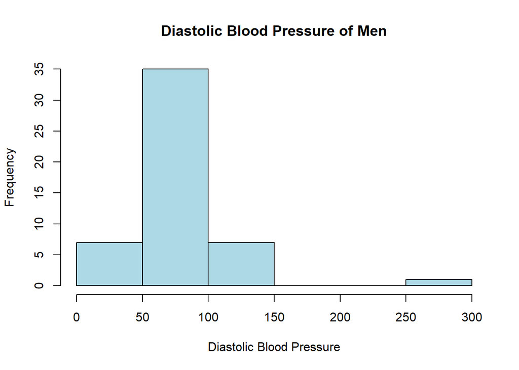

```r
# Histogram
hist(bp$diastolic, main = "Diastolic Blood Pressure of Men", xlab = "Diastolic Blood Pressure", ylab = "Frequency", col = "lightblue")
```

```r
# Clean the Data
outlier <- which(bp$diastolic > 150)
BPclean <- bp[-(outlier), ]
BPclean
```

```
 [1]  37  87  91  91  77  74 104  55  29  50  75 101  76  50 101  56 106  85  97
[20]  64  99  63  74  86  84 118  46  68  73  93  77  64  50  91  75  54  59  82
[39]  68  70 131 107  87 100  60  89  91  33  67
```

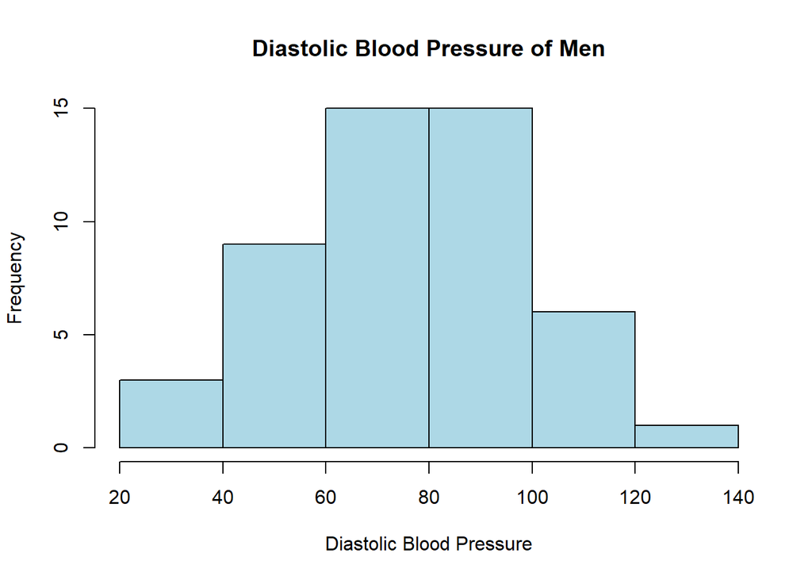

```r
hist(BPclean, main = "Diastolic Blood Pressure of Men", xlab = "Diastolic Blood Pressure", ylab = "Frequency", col = "lightblue")
```

# 3 Standardize the Data

```r
# Standardize the Data
Z_BP <- (bp$distolic-mean(bp$diastolic))/sd(bp$diastolic)
Z_BP
```

```
numeric(0)
```

```r
Z_BP_clean <- (BPclean-mean(BPclean))/sd(BPclean)
Z_BP_clean
```

```
 [1] -1.812919873  0.462517468  0.644552455  0.644552455  0.007429999
 [6] -0.129096241  1.236166164 -0.993762430 -2.176989848 -1.221306165
[11] -0.083587494  1.099639923 -0.038078747 -1.221306165  1.099639923
[16] -0.948253684  1.327183657  0.371499974  0.917604936 -0.584183709
[21]  1.008622429 -0.629692456 -0.129096241  0.417008721  0.325991227
[26]  1.873288619 -1.403341152 -0.402148722 -0.174604988  0.735569949
[31]  0.007429999 -0.584183709 -1.221306165  0.644552455 -0.083587494
[36] -1.039271177 -0.811727443  0.234973734 -0.402148722 -0.311131228
[41]  2.464902328  1.372692404  0.462517468  1.054131176 -0.766218696
[46]  0.553534961  0.644552455 -1.994954860 -0.447657469
```

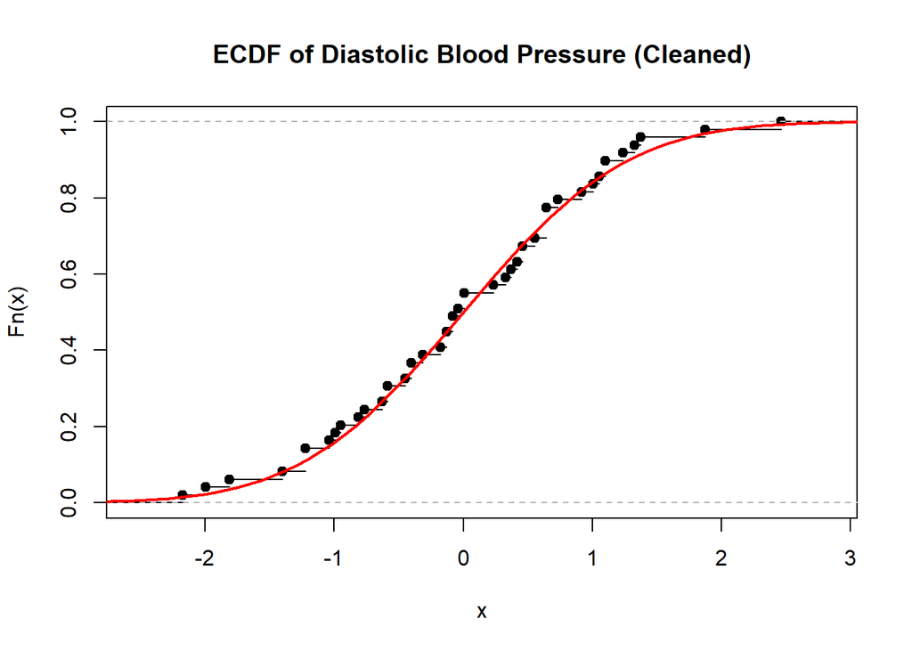

```r
# ECDF Plot
# par(mfrow=c(1,2))
# plot(ecdf(Z_BP), main = "ECDF of Diastolic Blood Pressure")
# curve(pnorm, from = -3, to = 6, add = T, col = "blue", lwd = 2)

plot(ecdf(Z_BP_clean), main = "ECDF of Diastolic Blood Pressure (Cleaned)")
curve(pnorm, from = -3, to = 6, add = T, col = "red", lwd = 2)
```

# 4 Shapiro-Wilk Test

Apply the Shapiro-Wilk’s test to both dataset (original and cleaned) to test if there is any evidence to contradict the assumption that diastolic blood pressure of men is normally distributed. Provide your R code, state the null and alternative hypotheses and interpret the p-values of the hypothesis tests in terms of the strength of the evidence for the alternative hypothesis.

- **Null Hypothesis (H0):** The diastolic blood pressure of men is normally distributed.
- **Alternative Hypothesis (H1):** The diastolic blood pressure of men is not normally distributed.
- **Significance Level:** α = 0.05
- **Decision Rule:** If p-value < α, reject H0.
- **Interpretation:** If p-value > α, fail to reject H0.

```r
shapiro.test(bp$diastolic)
```

```
    Shapiro-Wilk normality test

data:  bp$diastolic
W = 0.75477, p-value = 9.204e-08
```

```r
shapiro.test(BPclean)
```

```
    Shapiro-Wilk normality test

data:  BPclean
W = 0.99181, p-value = 0.9806
```

**Conclusion:**

The p-value of the shapiro-wilk test for the original data is less than 0.05, therefore we reject the null hypothesis that the diastolic blood pressure of men is normally distributed. The p-value of the shapiro-wilk test for the cleaned data is greater than 0.05, therefore we fail to reject the null hypothesis that the diastolic blood of men is normally distributed.

# 5 Equal Variance Test

The `groupdata.csv` datafile consists of measurements (variable X) for two independent groups 1 and 2 (variable GROUP).

## 5.1 Load the Data

```r
groupdata <- read.csv("../data/groupdata.csv", header = TRUE)
groupdata
```

| GROUP | X |
| --- | --- |
| 1 | 0.258519026 |
| 1 | 0.064308906 |
| 1 | 0.921451099 |
| 1 | 0.037559415 |
| 1 | 0.595196701 |
| 1 | 0.623567716 |
| 1 | 0.807390659 |
| 1 | 0.517506489 |
| 1 | 0.719946075 |
| 1 | 0.962919805 |

[output cut: 20 more lines]

```r
# Summary Statistics
summary(groupdata$X)
```

```
     Min.   1st Qu.    Median      Mean   3rd Qu.      Max.
0.0001556 0.3240551 0.4542163 0.4455609 0.5926862 0.9629198
```

Perform a two-sample Kolmogorov-Smirnov test to test whether the distribution of variable X for Group 1 is different from the distribution of variable X for Group 2. Provide your R code and output. Without performing any further tests for normality, what can you conclude from the results of the Kolmogorov-Smirnov test about the assumption of normality of variable X for each of the two independent groups? Justify your answer.

```r
group1 <- groupdata$X[groupdata$GROUP == 1]
group2 <- groupdata$X[groupdata$GROUP == 2]
ks.test(x = group1, y = group2)
```

```
    Exact two-sample Kolmogorov-Smirnov test

data:  group1 and group2
D = 0.53333, p-value = 0.02625
alternative hypothesis: two-sided
```

## 5.3 Equal Variance Test

Based on the results in Question 6, choose the appropriate test to compare the two independent group variances of variable X. Choose between the F test and the Fligner-Kileen test and justify your choice. Test the hypothesis at the 5% level of significance. Provide your R code, output and interpretation of the test.

```r
fligner.test(groupdata$X ~ groupdata$GROUP)
```

```
    Fligner-Killeen test of homogeneity of variances

data:  groupdata$X by groupdata$GROUP
Fligner-Killeen:med chi-squared = 10.827, df = 1, p-value = 0.001
```